# Personal Project Data Analysis 2

```python
import pandas as pd
import matplotlib.pyplot as plt
import seaborn as sns

print("pandas version:", pd.__version__)
#print("matplotlib.pyplot version:", plt.__version__)
print("seaborn version:", sns.__version__)
```

```
pandas version: 2.3.2
seaborn version: 0.13.2
```

This data is gathered from this website: https://www.rijdendetreinen.nl/en/open-data/train-archive

### Data Dictionary

Below you will find the data dictionary provided by Rijden-de-treinen.

Each row in these files represent a stop at a station. Each service at least departs from and arrives at a station (i.e. two rows). For each stop, you can find the name of the station, the arrival and departure time, delays and cancellations. The exact meaning of each column is explained below.

The source for this data is the real-time data from NS with live departure times, live arrival times and service updates. This data is also used in the app and website of Rijden Treinen.

#### Columns

- `Service:RDT-ID` *Unique identifier (service):* This is the ID that Rijden de Treinen uses for this service. It has no useful meaning beyond uniquely identifying a single service on a single date. This ID will occur more than once in the CSV files because this ID is unique for each service. There is also a column Stop:RDT-ID with a unique ID for each stop.
- `Service:Date` *Service date (schedule date):* The scheduled service date for this service. The service date is not always the same as the actual date. For example, a service that departs at 23:59 on 31 July and arrives at 02:00 on 1 August has a service date of 31 July. Delays do not affect the service date.
- `Service:Type` *Service type:* The service type, for example: *Intercity*, *Sprinter* or *ICE International*.
- `Service:Company` *Operator:* Company operating this service, like NS or Arriva.
- `Service:Train number` *Train number:* The train number (service number) for this service uniquely identifies this service on this date. This number is sometimes also communicated to passengers (especially for international trains). A single service may sometimes have multiple train numbers. For example, when a train is split in two parts, or when a train changes a train number on a major station halfway.
- `Service:Completely cancelled` *Service is fully cancelled:* This column is true when all stops of this service have been cancelled. Or in other words: when the train does not run at all.
- `Service:Partly cancelled` *Partially cancelled:* This column is true when one or more stops of this service have been cancelled. Or in other words: when the train does not run on a part of the route.
- `Service:Maximum delay` *Highest delay for this service:* The highest delay (**in minutes**) of all stops of this service.
- `Stop:RDT-ID` *Unique identifier (stop):* Unique identifier for this stop. This ID is unique for each stop in the dataset. It has no further useful meaning.
- `Stop:Station code` *Station code:* Code (abbreviation) of the station name. See also the [dataset with railway stations.](https://www.rijdendetreinen.nl/en/open-data/stations)
- `Stop:Station name` *Station name:* The name of the station.
- `Stop:Arrival time` *Arrival time:* Scheduled arrival time in **RFC 3339 format.** This column is empty when no arrival was scheduled.
- `Stop:Arrival delay` *Arrival delay:* Arrival delay **in minutes.** This column is empty when no arrival was scheduled.
- `Stop:Arrival cancelled` *Cancelled arrival:* This column is true when the arrival at this stop has been cancelled. This column is empty when no arrival was scheduled.
- `Stop:Departure time` *Departure time:* Scheduled departure time in **RFC 3339 format.** This column is empty when no departure was scheduled.
- `Stop:Departure delay` *Departure delay:* Departure delay **in minutes.** This column is empty when no departure was scheduled.
- `Stop:Departure cancelled` *Cancelled departure:* This column is true when the departure at this stop has been cancelled. This column is empty when no departure was scheduled.
- `Stop:Platform change` *Platform change:* This column is true when the platform of this stop has changed from the planned platform.
- `Stop:Planned platform` *Scheduled platform:* The originally scheduled platform for this service.
- `Stop:Actual platform` *Actual platform:* The platform that was actually used for this service.

```python
df = pd.read_parquet('Data/version_1_traject_Eindhoven_sittard_2019_2025.parquet')
df.head()
```

|  | Service:RDT-ID | Service:Date | Service:Type | Service:Company | Service:Train number | Service:Completely cancelled | Service:Partly cancelled | Service:Maximum delay | Stop:RDT-ID | Stop:Station code | Stop:Station name | Stop:Arrival time | Stop:Arrival delay | Stop:Arrival cancelled | Stop:Departure time | Stop:Departure delay | Stop:Departure cancelled | Stop:Platform change | Stop:Planned platform | Stop:Actual platform |
| --- | --- | --- | --- | --- | --- | --- | --- | --- | --- | --- | --- | --- | --- | --- | --- | --- | --- | --- | --- | --- |
| 0 | 738846 | 2019-01-01 | Intercity | NS | 2925 | False | False | 5 | 6220367 | EKZ | Enkhuizen | None | NaN | None | 2019-01-01T06:39:00+01:00 | 0.0 | False | False | 1 | 1 |
| 1 | 738846 | 2019-01-01 | Intercity | NS | 2925 | False | False | 0 | 6220388 | BKF | Bovenkarspel Flora | 2019-01-01T06:43:00+01:00 | 0.0 | False | 2019-01-01T06:43:00+01:00 | 0.0 | False | False | 1 | 1 |
| 2 | 738846 | 2019-01-01 | Intercity | NS | 2925 | False | False | 0 | 6220405 | BKG | Bovenkarspel-Grootebroek | 2019-01-01T06:45:00+01:00 | 0.0 | False | 2019-01-01T06:47:00+01:00 | 0.0 | False | False | 2 | 2 |
| 3 | 738846 | 2019-01-01 | Intercity | NS | 2925 | False | False | 0 | 6220435 | HKS | Hoogkarspel | 2019-01-01T06:52:00+01:00 | 0.0 | False | 2019-01-01T06:52:00+01:00 | 0.0 | False | False | 2 | 2 |
| 4 | 738846 | 2019-01-01 | Intercity | NS | 2925 | False | False | 0 | 6220479 | HNK | Hoorn Kersenboogerd | 2019-01-01T06:58:00+01:00 | 1.0 | False | 2019-01-01T06:59:00+01:00 | 0.0 | False | False | 1 | 1 |

```python
df.info()
```

```
<class 'pandas.core.frame.DataFrame'>
RangeIndex: 3828137 entries, 0 to 3828136
Data columns (total 20 columns):
 #   Column                        Dtype
---  ------                        -----
 0   Service:RDT-ID                int64
 1   Service:Date                  object
 2   Service:Type                  object
 3   Service:Company               object
 4   Service:Train number          int64
 5   Service:Completely cancelled  bool
 6   Service:Partly cancelled      bool
 7   Service:Maximum delay         int64
 8   Stop:RDT-ID                   int64
 9   Stop:Station code             object
 10  Stop:Station name             object
 11  Stop:Arrival time             object
 12  Stop:Arrival delay            float64
 13  Stop:Arrival cancelled        object
 14  Stop:Departure time           object
 15  Stop:Departure delay          float64
 16  Stop:Departure cancelled      object
 17  Stop:Platform change          bool
 18  Stop:Planned platform         object
 19  Stop:Actual platform          object
dtypes: bool(3), float64(2), int64(4), object(11)
memory usage: 507.5+ MB
```

```python
df.isnull().sum()
```

```
Service:RDT-ID                       0
Service:Date                         0
Service:Type                         0
Service:Company                      0
Service:Train number                 0
Service:Completely cancelled         0
Service:Partly cancelled             0
Service:Maximum delay                0
Stop:RDT-ID                          0
Stop:Station code                    0
Stop:Station name                    0
Stop:Arrival time               301082
Stop:Arrival delay              301082
Stop:Arrival cancelled          301082
Stop:Departure time             301259
Stop:Departure delay            301259
Stop:Departure cancelled        301259
Stop:Platform change                 0
Stop:Planned platform           422157
Stop:Actual platform            422157
dtype: int64
```

I wanted to check the Null values. This seems like a lot but I also see a pattern. I want to know what these values are.

```python
df[df["Stop:Arrival time"].isnull()].head(10)
```

|  | Service:RDT-ID | Service:Date | Service:Type | Service:Company | Service:Train number | Service:Completely cancelled | Service:Partly cancelled | Service:Maximum delay | Stop:RDT-ID | Stop:Station code | Stop:Station name | Stop:Arrival time | Stop:Arrival delay | Stop:Arrival cancelled | Stop:Departure time | Stop:Departure delay | Stop:Departure cancelled | Stop:Platform change | Stop:Planned platform | Stop:Actual platform |
| --- | --- | --- | --- | --- | --- | --- | --- | --- | --- | --- | --- | --- | --- | --- | --- | --- | --- | --- | --- | --- |
| 0 | 738846 | 2019-01-01 | Intercity | NS | 2925 | False | False | 5 | 6220367 | EKZ | Enkhuizen | None | NaN | None | 2019-01-01T06:39:00+01:00 | 0.0 | False | False | 1 | 1 |
| 16 | 738954 | 2019-01-01 | Intercity | NS | 2926 | False | False | 1 | 6220930 | MT | Maastricht | None | NaN | None | 2019-01-01T07:31:00+01:00 | 0.0 | False | True | 1 | 3 |
| 32 | 738996 | 2019-01-01 | Intercity | NS | 2929 | False | False | 3 | 6221087 | EKZ | Enkhuizen | None | NaN | None | 2019-01-01T07:39:00+01:00 | 0.0 | False | False | 1 | 1 |
| 48 | 739087 | 2019-01-01 | Intercity | NS | 2921 | False | False | 1 | 6221644 | EHV | Eindhoven | None | NaN | None | 2019-01-01T08:00:00+01:00 | 0.0 | False | False | 1 | 1 |
| 53 | 739092 | 2019-01-01 | Intercity | NS | 2928 | False | False | 2 | 6221711 | MT | Maastricht | None | NaN | None | 2019-01-01T08:01:00+01:00 | 0.0 | False | False | 3 | 3 |
| 69 | 739136 | 2019-01-01 | Intercity | NS | 2931 | False | False | 6 | 6221920 | EKZ | Enkhuizen | None | NaN | None | 2019-01-01T08:09:00+01:00 | 0.0 | False | False | 1 | 1 |
| 85 | 739146 | 2019-01-01 | Intercity | NS | 2927 | False | False | 1 | 6221985 | ASD | Amsterdam Centraal | None | NaN | None | 2019-01-01T08:11:00+01:00 | 0.0 | False | False | 7b | 7b |
| 94 | 739234 | 2019-01-01 | Intercity | NS | 2923 | False | False | 2 | 6222670 | EHV | Eindhoven | None | NaN | None | 2019-01-01T08:30:00+01:00 | 0.0 | False | False | 1 | 1 |
| 99 | 739237 | 2019-01-01 | Intercity | NS | 2930 | False | False | 4 | 6222759 | MT | Maastricht | None | NaN | None | 2019-01-01T08:31:00+01:00 | 0.0 | False | False | 1 | 1 |
| 115 | 739273 | 2019-01-01 | Intercity | NS | 3923 | False | False | 1 | 6222974 | EHV | Eindhoven | None | NaN | None | 2019-01-01T08:38:00+01:00 | 0.0 | False | False | 1 | 1 |

Lets take a look at the records that have the Arrival Time not filled in. There seem to be a lot of Stations that would be the end or start station of a traject. It is also curious that the very first record in the dataset has a Null value.

```python
df[df["Stop:Departure time"].isnull()].head(10)
```

|  | Service:RDT-ID | Service:Date | Service:Type | Service:Company | Service:Train number | Service:Completely cancelled | Service:Partly cancelled | Service:Maximum delay | Stop:RDT-ID | Stop:Station code | Stop:Station name | Stop:Arrival time | Stop:Arrival delay | Stop:Arrival cancelled | Stop:Departure time | Stop:Departure delay | Stop:Departure cancelled | Stop:Platform change | Stop:Planned platform | Stop:Actual platform |
| --- | --- | --- | --- | --- | --- | --- | --- | --- | --- | --- | --- | --- | --- | --- | --- | --- | --- | --- | --- | --- |
| 15 | 738846 | 2019-01-01 | Intercity | NS | 2925 | False | False | 0 | 6226302 | MT | Maastricht | 2019-01-01T10:00:00+01:00 | 3.0 | False | None | NaN | None | False | 3 | 3 |
| 31 | 738954 | 2019-01-01 | Intercity | NS | 2926 | False | False | 0 | 6228656 | EKZ | Enkhuizen | 2019-01-01T10:52:00+01:00 | 0.0 | False | None | NaN | None | False | 1 | 1 |
| 47 | 738996 | 2019-01-01 | Intercity | NS | 2929 | False | False | 0 | 6228721 | MT | Maastricht | 2019-01-01T11:00:00+01:00 | 1.0 | False | None | NaN | None | True | 2 | 3 |
| 52 | 739087 | 2019-01-01 | Intercity | NS | 2921 | False | False | 0 | 6223920 | MT | Maastricht | 2019-01-01T09:01:00+01:00 | 0.0 | False | None | NaN | None | False | 1 | 1 |
| 68 | 739092 | 2019-01-01 | Intercity | NS | 2928 | False | False | 0 | 6229925 | EKZ | Enkhuizen | 2019-01-01T11:22:00+01:00 | 0.0 | False | None | NaN | None | False | 1 | 1 |
| 84 | 739136 | 2019-01-01 | Intercity | NS | 2931 | False | False | 0 | 6230001 | MT | Maastricht | 2019-01-01T11:31:00+01:00 | 0.0 | False | None | NaN | None | True | 1 | 2 |
| 93 | 739146 | 2019-01-01 | Intercity | NS | 2927 | False | False | 0 | 6227535 | MT | Maastricht | 2019-01-01T10:31:00+01:00 | 0.0 | False | None | NaN | None | False | 1 | 1 |
| 98 | 739234 | 2019-01-01 | Intercity | NS | 2923 | False | False | 0 | 6225132 | MT | Maastricht | 2019-01-01T09:31:00+01:00 | 0.0 | False | None | NaN | None | False | 1 | 1 |
| 114 | 739237 | 2019-01-01 | Intercity | NS | 2930 | False | False | 0 | 6231235 | EKZ | Enkhuizen | 2019-01-01T11:52:00+01:00 | 1.0 | False | None | NaN | None | False | 1 | 1 |
| 119 | 739273 | 2019-01-01 | Intercity | NS | 3923 | False | False | 0 | 6225690 | HRL | Heerlen | 2019-01-01T09:41:00+01:00 | 0.0 | False | None | NaN | None | False | 5 | 5 |

Its the same for the departure time.

```python
example_id = df["Service:RDT-ID"].iloc[0]
df[df["Service:RDT-ID"] == example_id][[
    "Service:RDT-ID", "Stop:Station code", "Stop:Arrival time", "Stop:Departure time"
]]
```

|  | Service:RDT-ID | Stop:Station code | Stop:Arrival time | Stop:Departure time |
| --- | --- | --- | --- | --- |
| 0 | 738846 | EKZ | None | 2019-01-01T06:39:00+01:00 |
| 1 | 738846 | BKF | 2019-01-01T06:43:00+01:00 | 2019-01-01T06:43:00+01:00 |
| 2 | 738846 | BKG | 2019-01-01T06:45:00+01:00 | 2019-01-01T06:47:00+01:00 |
| 3 | 738846 | HKS | 2019-01-01T06:52:00+01:00 | 2019-01-01T06:52:00+01:00 |
| 4 | 738846 | HNK | 2019-01-01T06:58:00+01:00 | 2019-01-01T06:59:00+01:00 |
| 5 | 738846 | HN | 2019-01-01T07:03:00+01:00 | 2019-01-01T07:05:00+01:00 |
| 6 | 738846 | ASS | 2019-01-01T07:31:00+01:00 | 2019-01-01T07:31:00+01:00 |
| 7 | 738846 | ASD | 2019-01-01T07:37:00+01:00 | 2019-01-01T07:40:00+01:00 |
| 8 | 738846 | ASA | 2019-01-01T07:48:00+01:00 | 2019-01-01T07:48:00+01:00 |
| 9 | 738846 | UT | 2019-01-01T08:07:00+01:00 | 2019-01-01T08:09:00+01:00 |
| 10 | 738846 | HT | 2019-01-01T08:40:00+01:00 | 2019-01-01T08:41:00+01:00 |
| 11 | 738846 | EHV | 2019-01-01T08:59:00+01:00 | 2019-01-01T09:00:00+01:00 |
| 12 | 738846 | WT | 2019-01-01T09:17:00+01:00 | 2019-01-01T09:17:00+01:00 |
| 13 | 738846 | RM | 2019-01-01T09:30:00+01:00 | 2019-01-01T09:31:00+01:00 |
| 14 | 738846 | STD | 2019-01-01T09:46:00+01:00 | 2019-01-01T09:47:00+01:00 |
| 15 | 738846 | MT | 2019-01-01T10:00:00+01:00 | None |

This confirms my suspicions. The `Stop:Arrival time` is empty when its the first station in the traject

Now I want to see the average delay per stop in order to get a clear image about the delays.

```python
avg_delays = (
    df.groupby("Stop:Station name")[["Stop:Arrival delay", "Stop:Departure delay"]]
    .mean()
    .reset_index()
    .sort_values("Stop:Arrival delay", ascending=False)
)

print(avg_delays.head())
```

```
    Stop:Station name  Stop:Arrival delay  Stop:Departure delay
125            Zwolle           72.000000                   NaN
17    Arnhem Centraal           63.000000                  65.0
27              Bunde           41.818182                   3.0
38           Deventer           41.500000                  41.5
54   Geleen-Lutterade           40.000000                  31.0
```

I happen to know the station `Geleen-Lutterade` and I know this station does not belong in the standard routes of the intercity to Eindhoven. Let's see the plot.

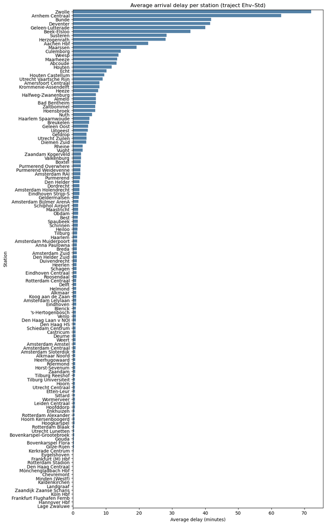

```python
plt.figure(figsize=(10,20))
sns.barplot(
    data=avg_delays,
    x="Stop:Arrival delay",
    y="Stop:Station name",
    color="steelblue"
)
plt.title("Average arrival delay per station (traject Ehv–Std)")
plt.xlabel("Average delay (minutes)")
plt.ylabel("Station")
plt.show()
```

These stations are way too much for just the standard route from Sittard to Eindhoven.

I want to investigate what these "Non-standard" stations are and how they look.

```python
df[df["Stop:Station name"] == "Geleen-Lutterade"]
```

|  | Service:RDT-ID | Service:Date | Service:Type | Service:Company | Service:Train number | Service:Completely cancelled | Service:Partly cancelled | Service:Maximum delay | Stop:RDT-ID | Stop:Station code | Stop:Station name | Stop:Arrival time | Stop:Arrival delay | Stop:Arrival cancelled | Stop:Departure time | Stop:Departure delay | Stop:Departure cancelled | Stop:Platform change | Stop:Planned platform | Stop:Actual platform |
| --- | --- | --- | --- | --- | --- | --- | --- | --- | --- | --- | --- | --- | --- | --- | --- | --- | --- | --- | --- | --- |
| 959668 | 4250754 | 2020-06-20 | Intercity | NS | 2985 | False | False | 0 | 37666673 | LUT | Geleen-Lutterade | 2020-06-21T00:50:00+02:00 | 25.0 | False | 2020-06-21T00:50:00+02:00 | 25.0 | False | False | None | None |
| 2969560 | 13168807 | 2024-03-15 | Intercity | NS | 2932 | False | True | 0 | 118888098 | LUT | Geleen-Lutterade | 2024-03-15T09:12:00+01:00 | 1.0 | False | None | NaN | None | False | 1 | 1 |
| 3376308 | 14888281 | 2024-11-29 | Intercity | NS | 2946 | False | True | 1 | 134416993 | LUT | Geleen-Lutterade | 2024-11-29T12:41:00+01:00 | 110.0 | False | None | NaN | None | False | 1 | 1 |
| 3651571 | 15993926 | 2025-05-17 | Intercity | NS | 2979 | False | True | 0 | 144717304 | LUT | Geleen-Lutterade | 2025-05-17T23:20:00+02:00 | 19.0 | False | 2025-05-17T23:20:00+02:00 | 23.0 | False | False | 2 | 2 |
| 3723827 | 16299102 | 2025-07-01 | Intercity | NS | 2983 | False | False | 0 | 147471082 | LUT | Geleen-Lutterade | 2025-07-02T00:20:00+02:00 | 45.0 | False | 2025-07-02T00:20:00+02:00 | 45.0 | False | False | 2 | 2 |

Only 5 stations across 6 years.

```python
df[df["Stop:Station name"] == "Bunde"]
```

|  | Service:RDT-ID | Service:Date | Service:Type | Service:Company | Service:Train number | Service:Completely cancelled | Service:Partly cancelled | Service:Maximum delay | Stop:RDT-ID | Stop:Station code | Stop:Station name | Stop:Arrival time | Stop:Arrival delay | Stop:Arrival cancelled | Stop:Departure time | Stop:Departure delay | Stop:Departure cancelled | Stop:Platform change | Stop:Planned platform | Stop:Actual platform |
| --- | --- | --- | --- | --- | --- | --- | --- | --- | --- | --- | --- | --- | --- | --- | --- | --- | --- | --- | --- | --- |
| 479074 | 2591876 | 2019-10-15 | Intercity | NS | 865 | False | False | 0 | 22550008 | BDE | Bunde | 2019-10-15T19:55:00+02:00 | 30.0 | False | 2019-10-15T19:55:00+02:00 | 0.0 | False | False | None | None |
| 684600 | 3359308 | 2020-02-09 | Intercity | NS | 857 | False | True | 0 | 29653693 | BDE | Bunde | 2020-02-09T17:55:00+01:00 | 403.0 | False | 2020-02-09T17:55:00+01:00 | 0.0 | False | False | None | None |
| 959670 | 4250754 | 2020-06-20 | Intercity | NS | 2985 | False | False | 0 | 37666675 | BDE | Bunde | 2020-06-21T00:56:00+02:00 | 24.0 | False | 2020-06-21T00:56:00+02:00 | 24.0 | False | False | 1 | 1 |
| 1091663 | 4876303 | 2020-09-18 | Intercity | NS | 831 | False | True | 0 | 43128181 | BDE | Bunde | 2020-09-18T11:25:00+02:00 | 0.0 | False | 2020-09-18T11:25:00+02:00 | 0.0 | False | False | None | None |
| 1311991 | 5877943 | 2021-02-22 | Intercity | NS | 842 | False | True | 0 | 52439484 | BDE | Bunde | 2021-02-22T11:35:00+01:00 | 0.0 | False | 2021-02-22T11:35:00+01:00 | 0.0 | True | False | None | None |
| 1315009 | 5898389 | 2021-02-22 | Intercity | NS | 300842 | False | True | 0 | 52441842 | BDE | Bunde | 2021-02-22T11:35:00+01:00 | 0.0 | False | 2021-02-22T11:35:00+01:00 | 0.0 | True | False | None | None |
| 1457657 | 6673639 | 2021-06-29 | Intercity | NS | 2974 | False | True | 0 | 59881629 | BDE | Bunde | 2021-06-29T19:35:00+02:00 | 0.0 | False | 2021-06-29T19:35:00+02:00 | 0.0 | False | False | None | None |
| 1490140 | 6787397 | 2021-07-16 | Intercity | NS | 851 | False | True | 0 | 60901045 | BDE | Bunde | 2021-07-16T16:25:00+02:00 | 0.0 | False | 2021-07-16T16:25:00+02:00 | 0.0 | False | False | None | None |
| 2190108 | 9934474 | 2022-10-26 | Intercity | NS | 860 | False | True | 0 | 89399142 | BDE | Bunde | 2022-10-26T16:05:00+02:00 | 3.0 | False | None | NaN | None | False | 2 | 2 |
| 2320083 | 10540579 | 2023-01-30 | Intercity | NS | 848 | False | True | 0 | 94901143 | BDE | Bunde | 2023-01-30T13:05:00+01:00 | 0.0 | False | None | NaN | None | False | 2 | 2 |
| 3507371 | 15389981 | 2025-02-18 | Intercity | NS | 2744 | False | True | 0 | 139310405 | BDE | Bunde | 2025-02-18T12:04:00+01:00 | 0.0 | False | None | NaN | None | False | 2 | 2 |

11 stations

```python
df[df["Stop:Station name"] == "Tilburg Universiteit"]
```

|  | Service:RDT-ID | Service:Date | Service:Type | Service:Company | Service:Train number | Service:Completely cancelled | Service:Partly cancelled | Service:Maximum delay | Stop:RDT-ID | Stop:Station code | Stop:Station name | Stop:Arrival time | Stop:Arrival delay | Stop:Arrival cancelled | Stop:Departure time | Stop:Departure delay | Stop:Departure cancelled | Stop:Platform change | Stop:Planned platform | Stop:Actual platform |
| --- | --- | --- | --- | --- | --- | --- | --- | --- | --- | --- | --- | --- | --- | --- | --- | --- | --- | --- | --- | --- |
| 3118706 | 13785002 | 2024-06-18 | Intercity | NS | 703687 | False | False | 0 | 124392186 | TBU | Tilburg Universiteit | 2024-06-19T00:31:00+02:00 | 0.0 | False | 2024-06-19T00:31:00+02:00 | 0.0 | False | False | 1 | 1 |
| 3119647 | 13792970 | 2024-06-19 | Intercity | NS | 703687 | False | False | 0 | 124457656 | TBU | Tilburg Universiteit | 2024-06-20T00:31:00+02:00 | 1.0 | False | 2024-06-20T00:31:00+02:00 | 1.0 | False | False | 1 | 1 |
| 3122723 | 13816259 | 2024-06-23 | Intercity | NS | 703622 | False | False | 0 | 124648480 | TBU | Tilburg Universiteit | 2024-06-23T07:29:00+02:00 | 1.0 | False | 2024-06-23T07:29:00+02:00 | 1.0 | False | False | 2 | 2 |

```python
example_id = 4250754
example_id = 13785002
df[df["Service:RDT-ID"] == example_id][[
    "Service:RDT-ID", "Stop:Station code", "Stop:Arrival time", "Stop:Departure time"
]]
```

|  | Service:RDT-ID | Stop:Station code | Stop:Arrival time | Stop:Departure time |
| --- | --- | --- | --- | --- |
| 3118700 | 13785002 | MT | None | 2024-06-18T23:01:00+02:00 |
| 3118701 | 13785002 | STD | 2024-06-18T23:16:00+02:00 | 2024-06-18T23:17:00+02:00 |
| 3118702 | 13785002 | RM | 2024-06-18T23:31:00+02:00 | 2024-06-18T23:32:00+02:00 |
| 3118703 | 13785002 | WT | 2024-06-18T23:46:00+02:00 | 2024-06-18T23:46:00+02:00 |
| 3118704 | 13785002 | EHV | 2024-06-19T00:02:00+02:00 | 2024-06-19T00:03:00+02:00 |
| 3118705 | 13785002 | TB | 2024-06-19T00:25:00+02:00 | 2024-06-19T00:28:00+02:00 |
| 3118706 | 13785002 | TBU | 2024-06-19T00:31:00+02:00 | 2024-06-19T00:31:00+02:00 |
| 3118707 | 13785002 | TBR | 2024-06-19T00:36:00+02:00 | 2024-06-19T00:36:00+02:00 |
| 3118708 | 13785002 | GZ | 2024-06-19T00:41:00+02:00 | 2024-06-19T00:41:00+02:00 |
| 3118709 | 13785002 | BD | 2024-06-19T00:47:00+02:00 | 2024-06-19T00:48:00+02:00 |
| 3118710 | 13785002 | ETN | 2024-06-19T00:56:00+02:00 | 2024-06-19T00:56:00+02:00 |
| 3118711 | 13785002 | RSD | 2024-06-19T01:06:00+02:00 | None |

```python
example_id = 13168807
df[df["Service:RDT-ID"] == example_id][[
    "Service:RDT-ID", "Stop:Station code", "Stop:Arrival time", "Stop:Departure time"
]]
```

|  | Service:RDT-ID | Stop:Station code | Stop:Arrival time | Stop:Departure time |
| --- | --- | --- | --- | --- |
| 2969559 | 13168807 | MT | None | 2024-03-15T09:01:00+01:00 |
| 2969560 | 13168807 | LUT | 2024-03-15T09:12:00+01:00 | None |
| 2969561 | 13168807 | STD | 2024-03-15T09:15:00+01:00 | 2024-03-15T09:17:00+01:00 |
| 2969562 | 13168807 | RM | 2024-03-15T09:31:00+01:00 | 2024-03-15T09:32:00+01:00 |
| 2969563 | 13168807 | WT | 2024-03-15T09:46:00+01:00 | 2024-03-15T09:46:00+01:00 |
| 2969564 | 13168807 | EHV | 2024-03-15T10:02:00+01:00 | 2024-03-15T10:04:00+01:00 |
| 2969565 | 13168807 | HT | 2024-03-15T10:22:00+01:00 | 2024-03-15T10:23:00+01:00 |
| 2969566 | 13168807 | UT | 2024-03-15T10:51:00+01:00 | 2024-03-15T10:53:00+01:00 |
| 2969567 | 13168807 | ASA | 2024-03-15T11:11:00+01:00 | 2024-03-15T11:11:00+01:00 |
| 2969568 | 13168807 | ASD | 2024-03-15T11:19:00+01:00 | 2024-03-15T11:23:00+01:00 |
| 2969569 | 13168807 | ASS | 2024-03-15T11:29:00+01:00 | 2024-03-15T11:29:00+01:00 |
| 2969570 | 13168807 | HN | 2024-03-15T11:55:00+01:00 | 2024-03-15T11:59:00+01:00 |
| 2969571 | 13168807 | HNK | 2024-03-15T12:03:00+01:00 | 2024-03-15T12:03:00+01:00 |
| 2969572 | 13168807 | HKS | 2024-03-15T12:10:00+01:00 | 2024-03-15T12:10:00+01:00 |
| 2969573 | 13168807 | BKG | 2024-03-15T12:15:00+01:00 | 2024-03-15T12:17:00+01:00 |
| 2969574 | 13168807 | BKF | 2024-03-15T12:19:00+01:00 | 2024-03-15T12:19:00+01:00 |
| 2969575 | 13168807 | EKZ | 2024-03-15T12:23:00+01:00 | None |

It seems that all the routes that ever came through Eindhoven and Sittard are in this dataset. This includes any non-standard routes or re-routed trains. I need to fix this before doing anything else.

```python
# 1) Parseer tijden voor sorteren binnen elke service (coalesce: Arr-time of Dep-time)
df = df.copy()

for col in ["Stop:Arrival time", "Stop:Departure time"]:
    df[col] = pd.to_datetime(df[col], errors="coerce", utc=True)

# 'sort_time' = eerste beschikbare tijd (arr of dep) zodat begin/eindstations kloppen
df["sort_time"] = df["Stop:Arrival time"].fillna(df["Stop:Departure time"])

df
```

|  | Service:RDT-ID | Service:Date | Service:Type | Service:Company | Service:Train number | Service:Completely cancelled | Service:Partly cancelled | Service:Maximum delay | Stop:RDT-ID | Stop:Station code | ... | Stop:Arrival time | Stop:Arrival delay | Stop:Arrival cancelled | Stop:Departure time | Stop:Departure delay | Stop:Departure cancelled | Stop:Platform change | Stop:Planned platform | Stop:Actual platform | sort_time |
| --- | --- | --- | --- | --- | --- | --- | --- | --- | --- | --- | --- | --- | --- | --- | --- | --- | --- | --- | --- | --- | --- |
| 0 | 738846 | 2019-01-01 | Intercity | NS | 2925 | False | False | 5 | 6220367 | EKZ | ... | NaT | NaN | None | 2019-01-01 05:39:00+00:00 | 0.0 | False | False | 1 | 1 | 2019-01-01 05:39:00+00:00 |
| 1 | 738846 | 2019-01-01 | Intercity | NS | 2925 | False | False | 0 | 6220388 | BKF | ... | 2019-01-01 05:43:00+00:00 | 0.0 | False | 2019-01-01 05:43:00+00:00 | 0.0 | False | False | 1 | 1 | 2019-01-01 05:43:00+00:00 |
| 2 | 738846 | 2019-01-01 | Intercity | NS | 2925 | False | False | 0 | 6220405 | BKG | ... | 2019-01-01 05:45:00+00:00 | 0.0 | False | 2019-01-01 05:47:00+00:00 | 0.0 | False | False | 2 | 2 | 2019-01-01 05:45:00+00:00 |
| 3 | 738846 | 2019-01-01 | Intercity | NS | 2925 | False | False | 0 | 6220435 | HKS | ... | 2019-01-01 05:52:00+00:00 | 0.0 | False | 2019-01-01 05:52:00+00:00 | 0.0 | False | False | 2 | 2 | 2019-01-01 05:52:00+00:00 |
| 4 | 738846 | 2019-01-01 | Intercity | NS | 2925 | False | False | 0 | 6220479 | HNK | ... | 2019-01-01 05:58:00+00:00 | 1.0 | False | 2019-01-01 05:59:00+00:00 | 0.0 | False | False | 1 | 1 | 2019-01-01 05:58:00+00:00 |
| ... | ... | ... | ... | ... | ... | ... | ... | ... | ... | ... | ... | ... | ... | ... | ... | ... | ... | ... | ... | ... | ... |
| 3828132 | 16713265 | 2025-08-31 | Intercity | NS | 302957 | True | True | 0 | 151097396 | EHV | ... | 2025-08-31 14:57:00+00:00 | 0.0 | True | 2025-08-31 14:59:00+00:00 | 0.0 | True | False | None | None | 2025-08-31 14:57:00+00:00 |
| 3828133 | 16713265 | 2025-08-31 | Intercity | NS | 302957 | True | True | 0 | 151097397 | WT | ... | 2025-08-31 15:16:00+00:00 | 0.0 | True | 2025-08-31 15:16:00+00:00 | 0.0 | True | False | None | None | 2025-08-31 15:16:00+00:00 |
| 3828134 | 16713265 | 2025-08-31 | Intercity | NS | 302957 | True | True | 0 | 151097398 | RM | ... | 2025-08-31 15:29:00+00:00 | 0.0 | True | 2025-08-31 15:30:00+00:00 | 0.0 | True | False | None | None | 2025-08-31 15:29:00+00:00 |
| 3828135 | 16713265 | 2025-08-31 | Intercity | NS | 302957 | True | True | 0 | 151097399 | STD | ... | 2025-08-31 15:45:00+00:00 | 0.0 | True | 2025-08-31 15:46:00+00:00 | 0.0 | True | False | None | None | 2025-08-31 15:45:00+00:00 |
| 3828136 | 16713265 | 2025-08-31 | Intercity | NS | 302957 | True | True | 0 | 151097400 | MT | ... | 2025-08-31 16:03:00+00:00 | 0.0 | True | NaT | NaN | None | False | None | None | 2025-08-31 16:03:00+00:00 |

3828137 rows × 21 columns

```python
# 2) Bepaal per service het begin- en eindstation (op basis van sort_time)
#    (neem ook company/type mee als je later wilt filteren op Intercity/NS)
cols_keep = ["Service:RDT-ID", "Service:Company", "Service:Type"]

# Sorteer binnen service
df_sorted = df.sort_values(["Service:RDT-ID", "sort_time"])

# Pak eerste en laatste station/stop
first_stops = (
    df_sorted.groupby("Service:RDT-ID")
    .agg(start_name=("Stop:Station name", "first"),
         start_code=("Stop:Station code", "first"))
)


last_stops = (
    df_sorted.groupby("Service:RDT-ID")
    .agg(end_name=("Stop:Station name", "last"),
         end_code=("Stop:Station code", "last"))
)

meta_base = (
    df_sorted.groupby("Service:RDT-ID")[["Service:Company", "Service:Type"]]
    .first()
)
```

```python
meta = (
    meta_base
    .join(first_stops)
    .join(last_stops)
    .reset_index()
)

meta
```

|  | Service:RDT-ID | Service:Company | Service:Type | start_name | start_code | end_name | end_code |
| --- | --- | --- | --- | --- | --- | --- | --- |
| 0 | 738846 | NS | Intercity | Enkhuizen | EKZ | Maastricht | MT |
| 1 | 738954 | NS | Intercity | Maastricht | MT | Enkhuizen | EKZ |
| 2 | 738996 | NS | Intercity | Enkhuizen | EKZ | Maastricht | MT |
| 3 | 739087 | NS | Intercity | Eindhoven | EHV | Maastricht | MT |
| 4 | 739092 | NS | Intercity | Maastricht | MT | Enkhuizen | EKZ |
| ... | ... | ... | ... | ... | ... | ... | ... |
| 300829 | 16702636 | NS | Intercity | Maastricht | MT | Enkhuizen | EKZ |
| 300830 | 16706001 | NS | Intercity | Maastricht | MT | Enkhuizen | EKZ |
| 300831 | 16706820 | NS | Intercity | Enkhuizen | EKZ | Maastricht | MT |
| 300832 | 16713264 | NS | Intercity | Maastricht | MT | Enkhuizen | EKZ |
| 300833 | 16713265 | NS | Intercity | Enkhuizen | EKZ | Maastricht | MT |

300834 rows × 7 columns

```python
# 3) Definieer jouw begin- en eindstationsets (namen of codes, kies 1 en blijf consistent)
south_starts = {"Heerlen", "Maastricht"}
north_ends   = {"Enkhuizen", "Alkmaar"}

north_starts = {"Enkhuizen", "Alkmaar"}
south_ends   = {"Heerlen", "Maastricht"}

# 4) Filter services die aan jouw voorwaarden voldoen (beide richtingen)
mask_south_to_north = meta["start_name"].isin(south_starts) & meta["end_name"].isin(north_ends)
mask_north_to_south = meta["start_name"].isin(north_starts) & meta["end_name"].isin(south_ends)

valid_services = meta.loc[mask_south_to_north | mask_north_to_south, "Service:RDT-ID"]

df_clean = df[df["Service:RDT-ID"].isin(valid_services)].copy()

print(f"Totaal services: {meta.shape[0]:,}")
print(f"Geselecteerde services (beide richtingen): {valid_services.nunique():,}")
print(f"Aantal rijen in df_clean: {df_clean.shape[0]:,}")
```

```
Totaal services: 300,834
Geselecteerde services (beide richtingen): 191,934
Aantal rijen in df_clean: 2,880,592
```

```python
avg_delays = (
    df_clean.groupby("Stop:Station name")[["Stop:Arrival delay", "Stop:Departure delay"]]
    .mean()
    .reset_index()
    .sort_values("Stop:Arrival delay", ascending=False)
)

print(avg_delays.head())
```

```
     Stop:Station name  Stop:Arrival delay  Stop:Departure delay
15               Bunde           71.666667              6.000000
9          Beek-Elsloo           43.777778             12.500000
54            Susteren           40.958333              2.166667
27    Geleen-Lutterade           40.000000             31.000000
22  Eindhoven Strijp-S           37.250000             23.500000
```

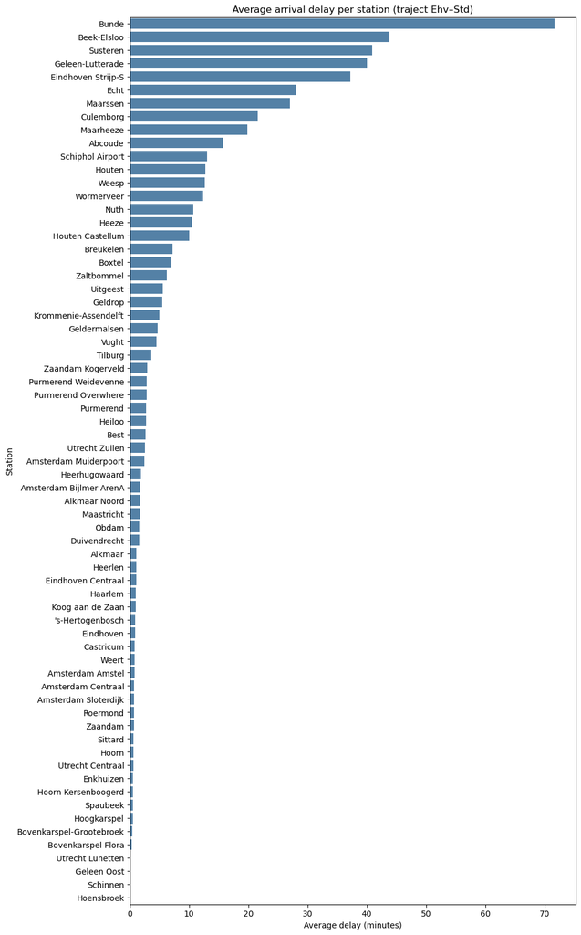

```python
plt.figure(figsize=(10,20))
sns.barplot(
    data=avg_delays,
    x="Stop:Arrival delay",
    y="Stop:Station name",
    color="steelblue"
)
plt.title("Average arrival delay per station (traject Ehv–Std)")
plt.xlabel("Average delay (minutes)")
plt.ylabel("Station")
plt.show()
```

```python
df_clean
```

|  | Service:RDT-ID | Service:Date | Service:Type | Service:Company | Service:Train number | Service:Completely cancelled | Service:Partly cancelled | Service:Maximum delay | Stop:RDT-ID | Stop:Station code | ... | Stop:Arrival time | Stop:Arrival delay | Stop:Arrival cancelled | Stop:Departure time | Stop:Departure delay | Stop:Departure cancelled | Stop:Platform change | Stop:Planned platform | Stop:Actual platform | sort_time |
| --- | --- | --- | --- | --- | --- | --- | --- | --- | --- | --- | --- | --- | --- | --- | --- | --- | --- | --- | --- | --- | --- |
| 0 | 738846 | 2019-01-01 | Intercity | NS | 2925 | False | False | 5 | 6220367 | EKZ | ... | NaT | NaN | None | 2019-01-01 05:39:00+00:00 | 0.0 | False | False | 1 | 1 | 2019-01-01 05:39:00+00:00 |
| 1 | 738846 | 2019-01-01 | Intercity | NS | 2925 | False | False | 0 | 6220388 | BKF | ... | 2019-01-01 05:43:00+00:00 | 0.0 | False | 2019-01-01 05:43:00+00:00 | 0.0 | False | False | 1 | 1 | 2019-01-01 05:43:00+00:00 |
| 2 | 738846 | 2019-01-01 | Intercity | NS | 2925 | False | False | 0 | 6220405 | BKG | ... | 2019-01-01 05:45:00+00:00 | 0.0 | False | 2019-01-01 05:47:00+00:00 | 0.0 | False | False | 2 | 2 | 2019-01-01 05:45:00+00:00 |
| 3 | 738846 | 2019-01-01 | Intercity | NS | 2925 | False | False | 0 | 6220435 | HKS | ... | 2019-01-01 05:52:00+00:00 | 0.0 | False | 2019-01-01 05:52:00+00:00 | 0.0 | False | False | 2 | 2 | 2019-01-01 05:52:00+00:00 |
| 4 | 738846 | 2019-01-01 | Intercity | NS | 2925 | False | False | 0 | 6220479 | HNK | ... | 2019-01-01 05:58:00+00:00 | 1.0 | False | 2019-01-01 05:59:00+00:00 | 0.0 | False | False | 1 | 1 | 2019-01-01 05:58:00+00:00 |
| ... | ... | ... | ... | ... | ... | ... | ... | ... | ... | ... | ... | ... | ... | ... | ... | ... | ... | ... | ... | ... | ... |
| 3828132 | 16713265 | 2025-08-31 | Intercity | NS | 302957 | True | True | 0 | 151097396 | EHV | ... | 2025-08-31 14:57:00+00:00 | 0.0 | True | 2025-08-31 14:59:00+00:00 | 0.0 | True | False | None | None | 2025-08-31 14:57:00+00:00 |
| 3828133 | 16713265 | 2025-08-31 | Intercity | NS | 302957 | True | True | 0 | 151097397 | WT | ... | 2025-08-31 15:16:00+00:00 | 0.0 | True | 2025-08-31 15:16:00+00:00 | 0.0 | True | False | None | None | 2025-08-31 15:16:00+00:00 |
| 3828134 | 16713265 | 2025-08-31 | Intercity | NS | 302957 | True | True | 0 | 151097398 | RM | ... | 2025-08-31 15:29:00+00:00 | 0.0 | True | 2025-08-31 15:30:00+00:00 | 0.0 | True | False | None | None | 2025-08-31 15:29:00+00:00 |
| 3828135 | 16713265 | 2025-08-31 | Intercity | NS | 302957 | True | True | 0 | 151097399 | STD | ... | 2025-08-31 15:45:00+00:00 | 0.0 | True | 2025-08-31 15:46:00+00:00 | 0.0 | True | False | None | None | 2025-08-31 15:45:00+00:00 |
| 3828136 | 16713265 | 2025-08-31 | Intercity | NS | 302957 | True | True | 0 | 151097400 | MT | ... | 2025-08-31 16:03:00+00:00 | 0.0 | True | NaT | NaN | None | False | None | None | 2025-08-31 16:03:00+00:00 |

2880592 rows × 21 columns

```python
example_id = 13168807
df_clean[df_clean["Service:RDT-ID"] == example_id][[
    "Service:RDT-ID", "Stop:Station code", "Stop:Arrival time", "Stop:Departure time"
]]
```

|  | Service:RDT-ID | Stop:Station code | Stop:Arrival time | Stop:Departure time |
| --- | --- | --- | --- | --- |
| 2969559 | 13168807 | MT | NaT | 2024-03-15 08:01:00+00:00 |
| 2969560 | 13168807 | LUT | 2024-03-15 08:12:00+00:00 | NaT |
| 2969561 | 13168807 | STD | 2024-03-15 08:15:00+00:00 | 2024-03-15 08:17:00+00:00 |
| 2969562 | 13168807 | RM | 2024-03-15 08:31:00+00:00 | 2024-03-15 08:32:00+00:00 |
| 2969563 | 13168807 | WT | 2024-03-15 08:46:00+00:00 | 2024-03-15 08:46:00+00:00 |
| 2969564 | 13168807 | EHV | 2024-03-15 09:02:00+00:00 | 2024-03-15 09:04:00+00:00 |
| 2969565 | 13168807 | HT | 2024-03-15 09:22:00+00:00 | 2024-03-15 09:23:00+00:00 |
| 2969566 | 13168807 | UT | 2024-03-15 09:51:00+00:00 | 2024-03-15 09:53:00+00:00 |
| 2969567 | 13168807 | ASA | 2024-03-15 10:11:00+00:00 | 2024-03-15 10:11:00+00:00 |
| 2969568 | 13168807 | ASD | 2024-03-15 10:19:00+00:00 | 2024-03-15 10:23:00+00:00 |
| 2969569 | 13168807 | ASS | 2024-03-15 10:29:00+00:00 | 2024-03-15 10:29:00+00:00 |
| 2969570 | 13168807 | HN | 2024-03-15 10:55:00+00:00 | 2024-03-15 10:59:00+00:00 |
| 2969571 | 13168807 | HNK | 2024-03-15 11:03:00+00:00 | 2024-03-15 11:03:00+00:00 |
| 2969572 | 13168807 | HKS | 2024-03-15 11:10:00+00:00 | 2024-03-15 11:10:00+00:00 |
| 2969573 | 13168807 | BKG | 2024-03-15 11:15:00+00:00 | 2024-03-15 11:17:00+00:00 |
| 2969574 | 13168807 | BKF | 2024-03-15 11:19:00+00:00 | 2024-03-15 11:19:00+00:00 |
| 2969575 | 13168807 | EKZ | 2024-03-15 11:23:00+00:00 | NaT |

```python
example_id = 739316
df_clean[df_clean["Service:RDT-ID"] == example_id][[
    "Service:RDT-ID", "Stop:Station code", "Stop:Arrival time", "Stop:Departure time"
]]
```

|  | Service:RDT-ID | Stop:Station code | Stop:Arrival time | Stop:Departure time |
| --- | --- | --- | --- | --- |
| 136 | 739316 | HRL | NaT | 2019-01-01 07:49:00+00:00 |
| 137 | 739316 | STD | 2019-01-01 08:04:00+00:00 | 2019-01-01 08:05:00+00:00 |
| 138 | 739316 | RM | 2019-01-01 08:19:00+00:00 | 2019-01-01 08:21:00+00:00 |
| 139 | 739316 | WT | 2019-01-01 08:35:00+00:00 | 2019-01-01 08:35:00+00:00 |
| 140 | 739316 | EHV | 2019-01-01 08:51:00+00:00 | 2019-01-01 08:57:00+00:00 |
| 141 | 739316 | HT | 2019-01-01 09:15:00+00:00 | 2019-01-01 09:18:00+00:00 |
| 142 | 739316 | UT | 2019-01-01 09:45:00+00:00 | 2019-01-01 09:48:00+00:00 |
| 143 | 739316 | ASA | 2019-01-01 10:06:00+00:00 | 2019-01-01 10:07:00+00:00 |
| 144 | 739316 | ASD | 2019-01-01 10:15:00+00:00 | 2019-01-01 10:19:00+00:00 |
| 145 | 739316 | ASS | 2019-01-01 10:25:00+00:00 | 2019-01-01 10:25:00+00:00 |
| 146 | 739316 | HN | 2019-01-01 10:51:00+00:00 | 2019-01-01 10:56:00+00:00 |
| 147 | 739316 | HNK | 2019-01-01 10:59:00+00:00 | 2019-01-01 11:00:00+00:00 |
| 148 | 739316 | HKS | 2019-01-01 11:07:00+00:00 | 2019-01-01 11:08:00+00:00 |
| 149 | 739316 | BKG | 2019-01-01 11:13:00+00:00 | 2019-01-01 11:16:00+00:00 |
| 150 | 739316 | BKF | 2019-01-01 11:18:00+00:00 | 2019-01-01 11:18:00+00:00 |
| 151 | 739316 | EKZ | 2019-01-01 11:22:00+00:00 | NaT |

```python
df_clean[df_clean["Stop:Station code"] == "ASB"][[
    "Service:RDT-ID", "Stop:Station code", "Stop:Station name", "Stop:Arrival time", "Stop:Departure time"
]]
```

|  | Service:RDT-ID | Stop:Station code | Stop:Station name | Stop:Arrival time | Stop:Departure time |
| --- | --- | --- | --- | --- | --- |
| 1492 | 742708 | ASB | Amsterdam Bijlmer ArenA | 2019-01-01 22:08:00+00:00 | 2019-01-01 22:08:00+00:00 |
| 3347 | 749104 | ASB | Amsterdam Bijlmer ArenA | 2019-01-02 22:08:00+00:00 | 2019-01-02 22:08:00+00:00 |
| 5201 | 755541 | ASB | Amsterdam Bijlmer ArenA | 2019-01-03 22:08:00+00:00 | 2019-01-03 22:08:00+00:00 |
| 7055 | 761984 | ASB | Amsterdam Bijlmer ArenA | 2019-01-04 22:08:00+00:00 | 2019-01-04 22:08:00+00:00 |
| 7117 | 762246 | ASB | Amsterdam Bijlmer ArenA | 2019-01-04 23:08:00+00:00 | 2019-01-04 23:08:00+00:00 |
| ... | ... | ... | ... | ... | ... |
| 3815706 | 16651713 | ASB | Amsterdam Bijlmer ArenA | 2025-08-24 16:21:00+00:00 | 2025-08-24 16:21:00+00:00 |
| 3815721 | 16651814 | ASB | Amsterdam Bijlmer ArenA | 2025-08-24 17:39:00+00:00 | 2025-08-24 17:39:00+00:00 |
| 3815738 | 16651868 | ASB | Amsterdam Bijlmer ArenA | 2025-08-24 16:52:00+00:00 | 2025-08-24 16:52:00+00:00 |
| 3815770 | 16652030 | ASB | Amsterdam Bijlmer ArenA | 2025-08-24 17:21:00+00:00 | 2025-08-24 17:21:00+00:00 |
| 3815803 | 16652179 | ASB | Amsterdam Bijlmer ArenA | 2025-08-24 17:51:00+00:00 | 2025-08-24 17:51:00+00:00 |

8686 rows × 5 columns

```python
stops_per_service = df_clean.groupby("Service:RDT-ID")["Stop:Station name"].apply(list)

station_counts = pd.Series(
    [station for service in stops_per_service for station in service]
).value_counts()

n_services = len(stops_per_service)
station_percent = station_counts / n_services * 100

station_percent = station_percent.reset_index()
station_percent.columns = ["Station", "Share (%)"]

print(stops_per_service)
print("Station Counts:")
print(station_counts)
print(station_percent)
```

```
Service:RDT-ID
738846      [Enkhuizen, Bovenkarspel Flora, Bovenkarspel-G...
738954      [Maastricht, Sittard, Roermond, Weert, Eindhov...
738996      [Enkhuizen, Bovenkarspel Flora, Bovenkarspel-G...
739092      [Maastricht, Sittard, Roermond, Weert, Eindhov...
739136      [Enkhuizen, Bovenkarspel Flora, Bovenkarspel-G...
                                  ...
16702636    [Maastricht, Sittard, Roermond, Weert, Eindhov...
16706001    [Maastricht, Sittard, Roermond, Weert, Eindhov...
16706820    [Enkhuizen, Bovenkarspel Flora, Bovenkarspel-G...
16713264    [Maastricht, Sittard, Roermond, Weert, Eindhov...
16713265    [Enkhuizen, Bovenkarspel Flora, Bovenkarspel-G...
Name: Stop:Station name, Length: 191934, dtype: object
Station Counts:
Amsterdam Sloterdijk    191934
Utrecht Centraal        191934
's-Hertogenbosch        191934
Roermond                191934
Sittard                 191934
                         ...
Schinnen                     1
Haarlem                      1
Koog aan de Zaan             1
Schiphol Airport             1
Utrecht Lunetten             1
Name: count, Length: 67, dtype: int64
                 Station   Share (%)
0   Amsterdam Sloterdijk  100.000000
1       Utrecht Centraal  100.000000
2       's-Hertogenbosch  100.000000
3               Roermond  100.000000
4                Sittard  100.000000
..                   ...         ...
62              Schinnen    0.000521
63               Haarlem    0.000521
64      Koog aan de Zaan    0.000521
65      Schiphol Airport    0.000521
66      Utrecht Lunetten    0.000521

[67 rows x 2 columns]
```

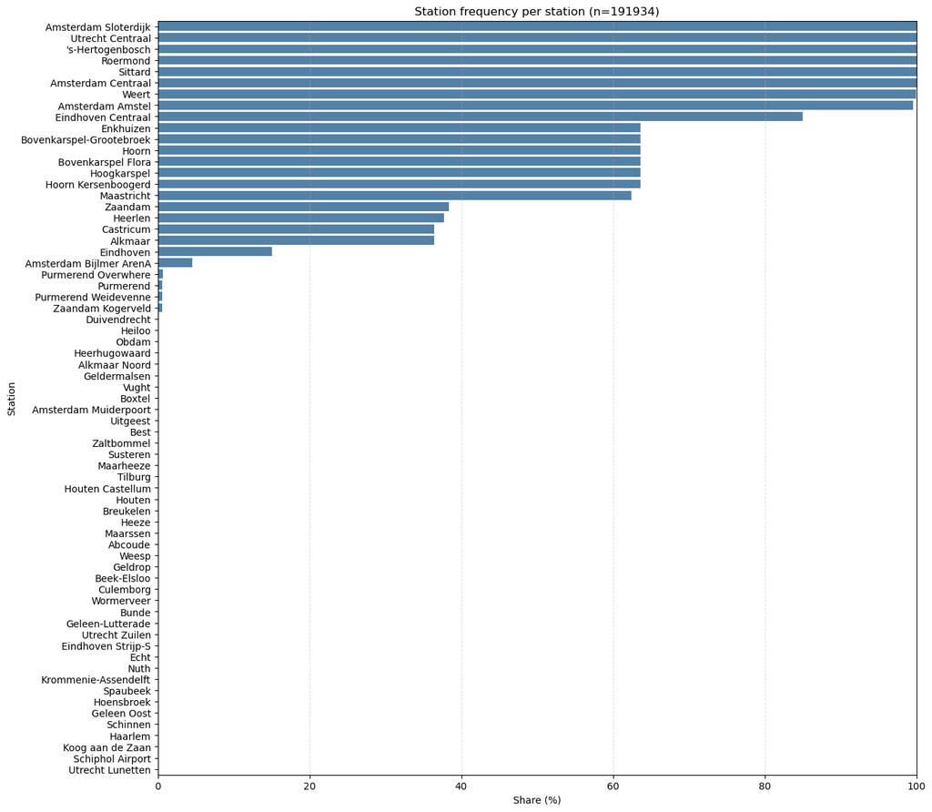

```python
plt.figure(figsize=(14,14))
sns.barplot(data=station_percent, x="Share (%)", y="Station", color="steelblue")
plt.title(f"Station frequency per station (n={n_services})")
plt.xlabel("Share (%)")
plt.ylabel("Station")
plt.xlim(0,100)
plt.grid(axis="x", ls="--", alpha=0.4)
plt.show()
```

I made this chart because I wanted to see the representation of each station in the dataset. There are too many small stations in this dataset which aren't part of the original route. I want to remove these to make sure there isn't any noise.

```python
df_clean[df_clean["Stop:Station name"] == "Zaandam Kogerveld"][[
    "Service:RDT-ID", "Stop:Station code", "Stop:Station name", "Stop:Arrival time", "Stop:Departure time"
]]
```

|  | Service:RDT-ID | Stop:Station code | Stop:Station name | Stop:Arrival time | Stop:Departure time |
| --- | --- | --- | --- | --- | --- |
| 7122 | 762246 | ZDK | Zaandam Kogerveld | 2019-01-04 23:39:00+00:00 | 2019-01-04 23:39:00+00:00 |
| 7144 | 762378 | ZDK | Zaandam Kogerveld | 2019-01-05 00:09:00+00:00 | 2019-01-05 00:09:00+00:00 |
| 8778 | 767732 | ZDK | Zaandam Kogerveld | 2019-01-05 23:39:00+00:00 | 2019-01-05 23:39:00+00:00 |
| 8800 | 767858 | ZDK | Zaandam Kogerveld | 2019-01-06 00:09:00+00:00 | 2019-01-06 00:09:00+00:00 |
| 19653 | 804903 | ZDK | Zaandam Kogerveld | 2019-01-11 23:39:00+00:00 | 2019-01-11 23:39:00+00:00 |
| ... | ... | ... | ... | ... | ... |
| 3804232 | 16602852 | ZDK | Zaandam Kogerveld | 2025-08-16 23:09:00+00:00 | 2025-08-16 23:09:00+00:00 |
| 3813805 | 16642089 | ZDK | Zaandam Kogerveld | 2025-08-22 23:10:00+00:00 | 2025-08-22 23:10:00+00:00 |
| 3814955 | 16647900 | ZDK | Zaandam Kogerveld | 2025-08-23 23:10:00+00:00 | 2025-08-23 23:10:00+00:00 |
| 3825669 | 16685017 | ZDK | Zaandam Kogerveld | 2025-08-29 23:09:00+00:00 | 2025-08-29 23:09:00+00:00 |
| 3826994 | 16690685 | ZDK | Zaandam Kogerveld | 2025-08-30 23:09:00+00:00 | 2025-08-30 23:09:00+00:00 |

1169 rows × 5 columns

Lets remove the stations that are represeted less than 500 times over these 6 years.

```python
rare_stations = station_counts[station_counts < 500].index

rare_stations
```

```
Index(['Duivendrecht', 'Heiloo', 'Obdam', 'Heerhugowaard', 'Alkmaar Noord',
       'Geldermalsen', 'Vught', 'Boxtel', 'Amsterdam Muiderpoort', 'Uitgeest',
       'Best', 'Zaltbommel', 'Susteren', 'Maarheeze', 'Tilburg',
       'Houten Castellum', 'Houten', 'Breukelen', 'Heeze', 'Maarssen',
       'Abcoude', 'Weesp', 'Geldrop', 'Beek-Elsloo', 'Culemborg', 'Wormerveer',
       'Bunde', 'Geleen-Lutterade', 'Utrecht Zuilen', 'Eindhoven Strijp-S',
       'Echt', 'Nuth', 'Krommenie-Assendelft', 'Spaubeek', 'Hoensbroek',
       'Geleen Oost', 'Schinnen', 'Haarlem', 'Koog aan de Zaan',
       'Schiphol Airport', 'Utrecht Lunetten'],
      dtype='object')
```

```python
services_with_rare = df_clean[df_clean["Stop:Station name"].isin(rare_stations)]["Service:RDT-ID"].unique()

services_with_rare
```

```
array([  811253,   811353,   811401, ..., 16676905, 16693721, 16713264],
      dtype=int64)
```

```python
df_clean = df_clean[~df_clean["Service:RDT-ID"].isin(services_with_rare)].copy()

df_clean
```

|  | Service:RDT-ID | Service:Date | Service:Type | Service:Company | Service:Train number | Service:Completely cancelled | Service:Partly cancelled | Service:Maximum delay | Stop:RDT-ID | Stop:Station code | ... | Stop:Arrival time | Stop:Arrival delay | Stop:Arrival cancelled | Stop:Departure time | Stop:Departure delay | Stop:Departure cancelled | Stop:Platform change | Stop:Planned platform | Stop:Actual platform | sort_time |
| --- | --- | --- | --- | --- | --- | --- | --- | --- | --- | --- | --- | --- | --- | --- | --- | --- | --- | --- | --- | --- | --- |
| 0 | 738846 | 2019-01-01 | Intercity | NS | 2925 | False | False | 5 | 6220367 | EKZ | ... | NaT | NaN | None | 2019-01-01 05:39:00+00:00 | 0.0 | False | False | 1 | 1 | 2019-01-01 05:39:00+00:00 |
| 1 | 738846 | 2019-01-01 | Intercity | NS | 2925 | False | False | 0 | 6220388 | BKF | ... | 2019-01-01 05:43:00+00:00 | 0.0 | False | 2019-01-01 05:43:00+00:00 | 0.0 | False | False | 1 | 1 | 2019-01-01 05:43:00+00:00 |
| 2 | 738846 | 2019-01-01 | Intercity | NS | 2925 | False | False | 0 | 6220405 | BKG | ... | 2019-01-01 05:45:00+00:00 | 0.0 | False | 2019-01-01 05:47:00+00:00 | 0.0 | False | False | 2 | 2 | 2019-01-01 05:45:00+00:00 |
| 3 | 738846 | 2019-01-01 | Intercity | NS | 2925 | False | False | 0 | 6220435 | HKS | ... | 2019-01-01 05:52:00+00:00 | 0.0 | False | 2019-01-01 05:52:00+00:00 | 0.0 | False | False | 2 | 2 | 2019-01-01 05:52:00+00:00 |
| 4 | 738846 | 2019-01-01 | Intercity | NS | 2925 | False | False | 0 | 6220479 | HNK | ... | 2019-01-01 05:58:00+00:00 | 1.0 | False | 2019-01-01 05:59:00+00:00 | 0.0 | False | False | 1 | 1 | 2019-01-01 05:58:00+00:00 |
| ... | ... | ... | ... | ... | ... | ... | ... | ... | ... | ... | ... | ... | ... | ... | ... | ... | ... | ... | ... | ... | ... |
| 3828132 | 16713265 | 2025-08-31 | Intercity | NS | 302957 | True | True | 0 | 151097396 | EHV | ... | 2025-08-31 14:57:00+00:00 | 0.0 | True | 2025-08-31 14:59:00+00:00 | 0.0 | True | False | None | None | 2025-08-31 14:57:00+00:00 |
| 3828133 | 16713265 | 2025-08-31 | Intercity | NS | 302957 | True | True | 0 | 151097397 | WT | ... | 2025-08-31 15:16:00+00:00 | 0.0 | True | 2025-08-31 15:16:00+00:00 | 0.0 | True | False | None | None | 2025-08-31 15:16:00+00:00 |
| 3828134 | 16713265 | 2025-08-31 | Intercity | NS | 302957 | True | True | 0 | 151097398 | RM | ... | 2025-08-31 15:29:00+00:00 | 0.0 | True | 2025-08-31 15:30:00+00:00 | 0.0 | True | False | None | None | 2025-08-31 15:29:00+00:00 |
| 3828135 | 16713265 | 2025-08-31 | Intercity | NS | 302957 | True | True | 0 | 151097399 | STD | ... | 2025-08-31 15:45:00+00:00 | 0.0 | True | 2025-08-31 15:46:00+00:00 | 0.0 | True | False | None | None | 2025-08-31 15:45:00+00:00 |
| 3828136 | 16713265 | 2025-08-31 | Intercity | NS | 302957 | True | True | 0 | 151097400 | MT | ... | 2025-08-31 16:03:00+00:00 | 0.0 | True | NaT | NaN | None | False | None | None | 2025-08-31 16:03:00+00:00 |

2855495 rows × 21 columns

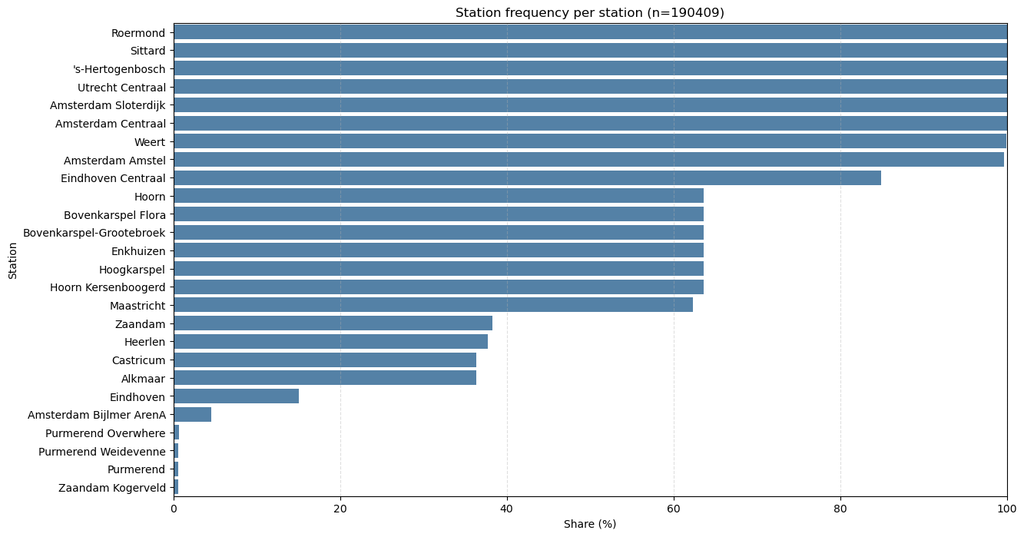

```python
stops_per_service = df_clean.groupby("Service:RDT-ID")["Stop:Station name"].apply(list)

station_counts = pd.Series(
    [station for service in stops_per_service for station in service]
).value_counts()

n_services = len(stops_per_service)
station_percent = station_counts / n_services * 100

station_percent = station_percent.reset_index()
station_percent.columns = ["Station", "Share (%)"]

plt.figure(figsize=(14,8))
sns.barplot(data=station_percent, x="Share (%)", y="Station", color="steelblue")
plt.title(f"Station frequency per station (n={n_services})")
plt.xlabel("Share (%)")
plt.ylabel("Station")
plt.xlim(0,100)
plt.grid(axis="x", ls="--", alpha=0.4)
plt.show()
```

This looks better to use. These stations will be the ones I can use for predictions. Now lets start with some feature engineering.

```python
avg_delays = (
    df_clean.groupby("Stop:Station name")[["Stop:Arrival delay", "Stop:Departure delay"]]
    .mean()
    .reset_index()
    .sort_values("Stop:Arrival delay", ascending=False)
)

print(avg_delays.head())
```

```
          Stop:Station name  Stop:Arrival delay  Stop:Departure delay
25        Zaandam Kogerveld            2.889081              3.032986
19     Purmerend Weidevenne            2.754325              2.720486
18      Purmerend Overwhere            2.714762              2.611390
17                Purmerend            2.659170              2.759965
3   Amsterdam Bijlmer ArenA            1.680737              1.731793
```

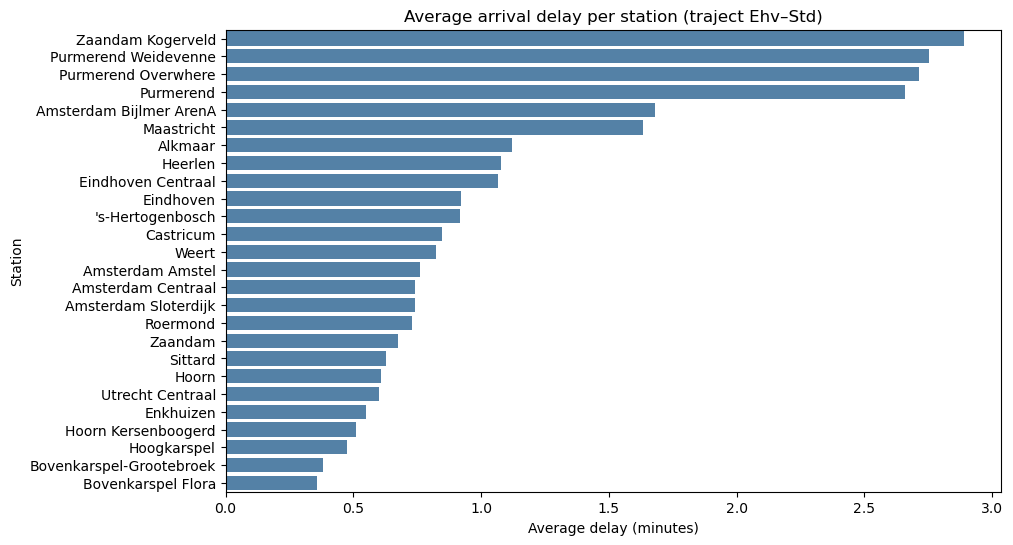

```python
plt.figure(figsize=(10,6))
sns.barplot(
    data=avg_delays,
    x="Stop:Arrival delay",
    y="Stop:Station name",
    color="steelblue"
)
plt.title("Average arrival delay per station (traject Ehv–Std)")
plt.xlabel("Average delay (minutes)")
plt.ylabel("Station")
plt.show()
```

From this dataset, the average delay is not that much. The trains here are fairly on time. This would also beg the question how possible it really is to be able to predict the delay if delay is defined by > 5 minutes of delay.

```python
import os

path = "Data/version_3_traject_Eindhoven_sittard_2019_2025.parquet"

if not os.path.exists(path):
    df_clean.to_parquet(
        path,
        engine="pyarrow",       # snel en efficiënt
        compression="snappy",
        index=False
    )
else:
    print("Bestand bestaat al")
```

```
Bestand bestaat al
```